# hydrotoolbox, a Package for Hydrometeorological Data Management

The hydrometeorological data provided by federal agencies, research groups and private companies tend to be heterogeneous: records are kept in different formats, quality control processes are not standardized and may even vary within a given agency, variables are not always recorded with the same temporal resolution, and there are data gaps and incorrectly recorded values. Once these problems are dealt with, it is useful to have tools to safely store and manipulate the series, providing temporal aggregation, interactive visualization for analysis, static graphics to publish and/or communicate results, techniques to correct and/or modify the series, among others. Here we introduce a package written in the R language using object-oriented programming and designed to accomplish these objectives, giving to the user a general framework for working with any kind of hydrometeorological series. We present the package design, its strengths, limitations and show its application for two real cases.

Ezequiel Toum (IANIGLA-CONICET) , Pierre Pitte (IANIGLA-CONICET)  
2023-11-01

## 1 Introduction

Data management has generated growing interest among the scientific community (Venkatraman 2013; Donoho 2017), driven by the proliferation of data sharing through the internet, new measurement techniques and equipment, and open and free access to information obtained from remote sensing. It is also fueled by new and growing demands from agencies and governments (national and/or regional) for data-informed decision-making. To realize the full potential of the available information, there is a need for accurate and efficient tools that can pre-process these vast and heterogeneous data into more convenient data sets (Addor et al. 2020).  
The hydrological community uses data from hydrometeorological stations, remote sensing observations and outputs from climatic and/or hydrological models (Beven 2012). These data types may include (but are not limited to):

1. **remote sensing**: snow cover images, soil humidity, glacier cover areas, digital elevation models.
2. **hydro-met stations**: air temperature, relative humidity, incoming solar radiation, atmospheric pressure, precipitation, streamflow records.
3. **numerical weather models**: air temperature, precipitation, and wind speed forecasting.
4. **hydrological models**: evolution of the snowpack, simulated streamflow, infiltration rates.
5. **large-sample hydrology datasets**

Data from remote sensing and climate models is distributed in standardized formats (e.g., *.nc*, *.tiff*, *.grb*) and therefore there are standardized tools to manipulate them (Conrad et al. 2015; Hijmans 2017; Pierce 2019). This is not the case for hydrometeorological data as each agency, research group or private company has its own standards. Therefore, the formats, publication frequency, temporal resolution and quality control vary. As an example, in Argentina, the organizations that manage hydrological data tend to use proprietary software: a) the *Autoridad Interjurisdiccional de las Cuencas de los ríos Limay, Neuquén* *y Negro* (AIC) uses DIMS (Dynamic Integrated Monitoring System), b) the *Sistema Nacional de Información Hídrica* (SNIH) works with Mnemos, and c) the *Instituto Nacional del Agua* (INA) uses their own software (personal communication).

The R language has gained a central role within the hydrological community during the last decade because it allows the user to: a) download and work with multiple data types and formats, b) extract, manipulate and order data, c) develop hydrological models, d) conduct statistical analyses, e) view results, and f) export images and documents ready for publication. Slater et al. (2019) pointed out the benefits and advantages of using R in the hydrological field: (1) it democratizes science and numerical literacy; (2) it helps the research to be reproducible and open; (3) provides statistical tools; (4) allows connection to and from other languages; and (5) has the support from a constantly growing community. Indeed the R community has developed many packages for managing hydrological data (https://cran.r-project.org/web/views/Hydrology.html), but they tend to be either focused on Europe and North America or lack a general-purpose framework for efficiently and safely storing and manipulating hydrometeorological series:

1. **hddtools** (Vitolo 2017): is designed to facilitate access to a variety of online open data sources relevant for hydrologists and, more generally, environmental scientists and practitioners. It includes functionality for Koppen Climate Classification, Global Runoff Data Centre, Data60UK, MOPEX (USA) and SEPA (Scotland).
2. **climate** (Czernecki et al. 2020): allows automatic downloading of OGIMET, University of Wyoming (atmospheric vertical profiling data), Polish Institute of Meteorology and Water Management (National Research Institute) and National Oceanic & Atmospheric Administration (NOAA).
3. waterData (Ryberg and Vecchia 2017): imports U.S. Geological Survey (USGS) daily hydrologic data from USGS web services, plots the data, addresses some common data problems, calculates and plots anomalies.
4. hydroTSM (Zambrano-Bigiarini 2020): provides functions for management, analysis, interpolation and plotting of time series used in hydrology and related environmental sciences. This package is highly oriented towards hydrological modeling tasks.
5. dataRetrieval (De Cicco et al. 2018): is a collection of functions that help to retrieve U.S. Geological Survey (USGS) and U.S. Environmental Protection Agency (EPA) water quality and hydrology data from web services.
6. hyfo (Xu 2020): is a package with focus on processing and visualization of hydrological data and climate forecasting. Main function includes data extraction, data downscaling, resampling, gap filler of precipitation, bias correction of forecasting data, flexible time series plot, and spatial map generation.

hydrotoolbox (Toum 2022) is an R package developed using R’s object-oriented programming system (S4 classes; Chambers (2017)) that provides a general framework for efficiently storing and manipulating multiple hydrometeorological datasets, exploiting not only S4 advantages but base R’s copy on modify semantics. The series and its metadata (e.g.: geo-referenced location, river basin name, country, among others) are agglomerated in a single class object, allowing for an effective management of vast and heterogeneous hydrometeorological data. hydrotoolbox also provides a general set of methods regarding: a) reading multiple datasets with their unique data formats (i.e. delimited files such as comma-separated values (CSV) and tab-separated values (TSV) and excel files), b) static and interactive time-series plotting, c) data manipulation, d) data temporal aggregation, among others. In addition, the current version (v 1.1.2) has specific functions for reading data from Argentina and Chile. Despite this fact, we want to stress that every user can combine other R functions or packages for downloading and reading data (including those coming from large-sample hydrological datasets; Addor et al. (2020)) with the functionality of the package.

The rest of this work is organized as follows: in the **Package design** section we describe the underlying ideas with a brief description of the classes, subclasses, methods and functions that hydrotoolbox offers. In the **Case studies section** we show two applied examples: the first deals with a hydrometerological data set and the second deals with post-processing the results of a modeling exercise with the HBV.IANIGLA model (Toum 2021; Toum et al. 2021). These cases lead to discussion about the package performance. We conclude with a discussion of possible improvements and ways to extend the functionality hydrotoolbox.

## 2 Package design

hydrotoolbox uses the object-oriented programming (OOP) paradigm, a feature that makes the package flexible and allows other programmers to extend its functionality. In this package, the properties are related to the hydrometeorological variables and the methods with functions for these objects manipulation. The following principles guided the design of hydrotoolbox:

1. **The time series of each variable must be grouped into stations**, as they are organized based on their geographic location. This allows series registered in the same station or at different ones to be compared without losing their position, a fundamental aspect for a correct physical interpretation of the data.
2. **Modifications must be recorded in the same file**. Most time series have errors that need to be corrected. This could happen because the time series are discontinuous, the instruments fail, the variables are not all measured in the same temporal resolution, because of power cuts, or because local natural conditions induce erroneous measurements (e.g., snowfall undercatch due to wind; Goodinson and Louie (1998)). Errors are corrected in successive steps but it is crucial to have access to all versions of the series. This principle also seeks to avoid having multiple records of the same variable in a given station. The reader will find an example in the *Case studies* section.
3. **Expedited visualization**. Fast and flexible visualization techniques are a powerful tool for analyzing and communicating results. The series should be able to be viewed statically and dynamically.
4. **There should be general functions for data manipulation** to reduce the need to permanently create custom functions.
5. **Open-ended design** to incorporate new objects and/or methods to continue expanding the package’s functionality.

### 2.1 Classes and subclasses

Following the first design principle, there is a class and two subclasses for managing hydrometereological data (Figure 1). The class, called `hydromet`, contains the station’s metadata (e.g., geographic coordinates, name of the basin, province, country, unique identifier, etc.). The two subclasses correspond to **(a)** data from meteorological stations and **(b)** data derived from modeling. The `hydromet_station` subclass contains a table for each measured variable (some of them are shown in Table 1) in combination with the metadata, allowing users to store in a single object all the information concerning an hydrometeorological station.

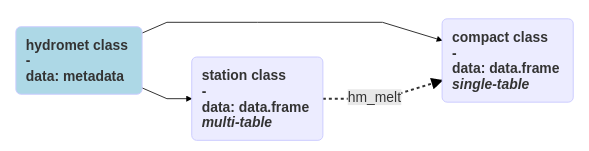

Figure 1: Classes for hydrometeorological data in $\textbf{hydrotoolbox}$ package. Arrows indicate the class that each entity inherits from. The dotted arrow means that an $\texttt{hydromet\_station}$ class can be transformed (by the $\texttt{hm\_melt}$ method) to a $\texttt{hydromet\_compact}$ class object.

The remaining subclass, called `hydromet_compact`, stores all series in a single table (called `compact`). It was created so that users could store input/output data from models or to save the same variable to perform regional analyzes (e.g., precipitation series recorded in different rain gauges).

Table 1: Eight out of forty hydrometeorological variables supported in $\texttt{hydromet_station}$ class (use $\texttt{slotNames(x = "hydromet_station")}$ to see all of them). In the package most of them are rectangular tables containing date series in their first column ($\texttt{Date}$ and $\texttt{POSIX*}$ classes are allowed).

| Slot | Variable |
| --- | --- |
| hq | water-height vs stream-discharge measurements |
| hw | water height level records |
| qh | hourly mean river discharge |
| qd | daily mean river discharge |
| qm | monthly mean river discharge |
| qa | annual river discharge |
| wspd | wind speed |
| wdir | wind direction |
| . | . |
| . | . |
| . | . |

### 2.2 Methods

The present package’s version provides a set of data processing operations (methods) widely required in hydrology such as: temporal aggregation, interactive and static visualization, series modification and statistical summaries. Table 2 provides a complete list accompanied with a brief description. Also, to make the package more user-friendly, all the methods for object manipulation follow the syntax `hm_action`; the `hm_` prefix being indicative of the superclass (`hydromet`) and the action being indicative of what it does. We believe that this feature greatly eases its application.

Table 2: Processing operations for object manipulation in the hydrotoolbox package.

| Method | Description |
| --- | --- |
| $\texttt{hm_agg}$ | temporally aggregates data |
| $\texttt{hm_build_generic}$ | automatically loads raw data inside the $\texttt{hydromet_station}$ object |
| $\texttt{hm_create}$ | constructs the $\texttt{hydromet}$ class and its subclasses |
| $\texttt{hm_get}$ | extracts the required table (or metadata) from the object |
| $\texttt{hm_melt}$ | merges several tables into a single one and set it into a $\texttt{hydromet_compact}$ class object |
| $\texttt{hm_mutate}$ | creates, modifies and deletes columns inside an object table (slot) |
| $\texttt{hm_name}$ | changes data frame column names |
| $\texttt{hm_plot}$ | makes static and dynamic graphs of the required hydrometeorological variables |
| $\texttt{hm_report}$ | gets basic statistic and a table with missing data |
| $\texttt{hm_set}$ | assigns the (meta)data to an $\texttt{hydromet}$ class or subclass object |
| $\texttt{hm_show}$ | shows the head or tail of the tables inside the object |
| $\texttt{hm_subset}$ | subsets the required table |

Although more details and examples about each of the methods are given in the **Case studies** section and in the package documentation and vignettes (Toum 2022), in the next lines we explain the use of `hm_build_generic`. This is a core package function, since it allows to automatically load raw hydrometeorological data inside an `hydromet_station` class object. Figure 2 depicts five different compatible rectangular data configurations. The upper scheme shows allowed configurations for any delimited type file (Wickham et al. 2022): a) all time series are stored in a single file with the first column being the date and the others numeric time series (measured variables), b) every variable is saved in a single file containing the date, the time series and other kind of data (like data-quality flags).  
Another widely used file type to store hydrometeorological measurements are excel files. The bottom scheme of Figure 2 depicts the three approaches: a) all time series are stored in a single file and sheet, b) every sheet (all in the same file) contains a variable (non-numeric columns allowed), and c) multiple files storing a single variable.

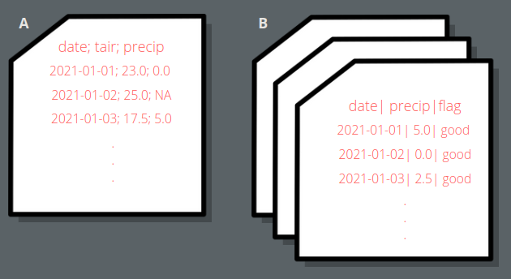

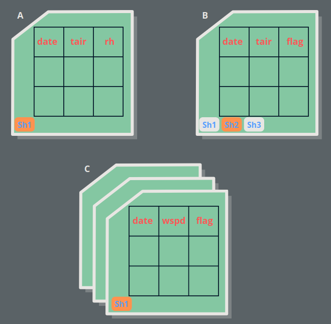

Figure 2: Rectangular data formats/file types compatible with the $\texttt{hm\_build\_generic}$ function. Top scheme depicts allowed delimited file arrangements while the bottom scheme is for excel files.

The use of this function is illustrated with two examples (the data can be downloaded from https://gitlab.com/ezetoum27/hydrotoolbox/-/tree/master/my_data), but the user can find full-covered documentation using the `??hm_build_generic` command.

```r
#* This code example shows how to use
#* the hm_build_generic() method to
#* automatically load raw hydrometeorological
#* data

library(hydrotoolbox)
library(readr)
library(readxl)

# path to data
my_path <- "./home/my_folder/my_data"

#+++++++++++++++++++
# Rectangular data
#+++++++++++++++++++
#* Case B: multiple files (one per variable)
hm_create(class_name = "station") %>%
 hm_build_generic(path = my_path,
                  file_name = c("h_relativa_cuevas.csv",
                                "p_atm_cuevas.csv",
                                "precip_total_cuevas.csv",
                                "temp_aire_cuevas.csv",
                                "vel_viento_cuevas.csv"),
                  slot_name = c("rh", "patm", "precip",
                                "tair", "wspd"),
                  by = c("hour", "45 min", "30 min", "1 hour", "15 min"),
                  FUN = read_csv  ) %>%
 hm_show()


#+++++++++++++++++++
# Excel files
#+++++++++++++++++++
#* Case B: single file - multiple sheets (one per variable)
hm_create(class_name = "station") %>%
 hm_build_generic(path = my_path,
                  file_name = "mnemos_guido.xlsx",
                  slot_name = c("qd", "evap",
                                "tair","tmax",
                                "tmin"),
                  by = c(q = "day", evap =  "day",
                         tair = "6 hour", tmax = "day",
                         tmin = NULL),
                  FUN = read_excel,
                  sheet = c(1L:5L),
                  skip = 3,
                  out_name = list( c("q_m3/s", "flag"),
                                   c("evap_mm", "flag"),
                                   c("tair", "flag"),
                                   c("tmax", "flag"),
                                   c("tmin", "flag")
                  )
 ) %>%
 hm_show()
```

## 3 Case studies

### 3.1 Daily streamflow record at the Guido station (Mendoza - Argentina)

The following example illustrates how to work with a time-series recorded in an Excel file with a single sheet (Case **A** in the **bottom** panel of Figure 2). This variable is measured at a station located in the Mendoza River basin from Argentina, a watershed that covers an area of approximately $7110 \, km^2$ and provides water to almost $1m$ inhabitants (Figure 3).

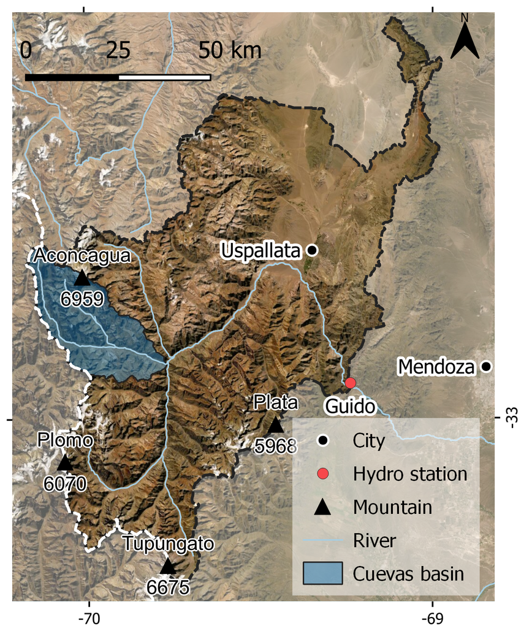

Figure 3: Map of the Mendoza basin including Guido hydrological station, cities, river and main mountain summits for reference.

In order to explore the data, we propose the following operations:

1. Build the station and obtain basic statistics of the data (`hm_build_generic`, `hm_report` and `hm_set` methods will be used).
2. Make a visual inspection of the series with `hm_plot`.
3. Smooth the streamflow record using a five days moving average windows. `hm_mutate` allows data manipulation and it can be combined with the user’s or other package’s functions via `FUN` and `...` arguments.
4. Aggregate the series to monthly average values (via `hm_agg`).
5. Plot results for publishing using the ggplot2 (Wickham 2016) output of `hm_plot`.

The first step is to load the original data in a `hydromet_station` that we are going to called *guido*.

```r
library(hydrotoolbox)
library(readxl)

# package's data-base
path <- system.file("extdata", package = "hydrotoolbox")

# station building
guido <-
  hm_create(class_name = "station") %>%
  hm_build_generic(path = path,
                   file_name = "snih_qd_guido.xlsx",
                   slot_name = "qd",
                   by = "1 day",
                   out_name = list("q_m3/s"),
                   sheet = 1L,
                   FUN = read_excel)
```

```r
# set the basin area
guido <-
  guido %>%
  hm_set(basin_area = 7110)

# get streamflow's report
guido %>%
  hm_report(slot_name = "qd")
```

```
$stats
           date    q_m3/s
min  1956-07-01   8.00000
max  2020-06-30 401.00000
mean       <NA>  44.47951
sd         <NA>  36.53992

$miss_data
$miss_data$`q_m3/s`
       first       last time_steps
1 1962-09-01 1962-09-30         30
2 1970-02-13 1970-02-14          2
3 1976-06-22 1976-07-31         40
4 1985-06-01 1985-06-30         30
5       <NA>       <NA>        102

$miss_data$comment
[1] "Missings total are in the last row."
```

Another essential part of the workflow is data visualization (Wickham and Grolemund 2017). The user of hydrotoolbox can use the `hm_plot` function and switch between static and interactive versions of the plot (using the `interactive = TRUE` argument). Internally, this function uses ggplot2 and plotly (Wickham 2016; Sievert 2020) to reproduce time-series plots and provides several arguments to set axes labels, define colors, line thickness and type, transparency, among others. The following example shows how to plot the mean daily streamflow. To see the interactive version of Figure 4 please visit the HTML (online) version of the article.

```r
# ggplot2 daily flow
guido %>%
  hm_plot(slot_name = "qd",
          col_name = list( "q_m3/s" ),
          interactive = FALSE,
          line_color = "dodgerblue",
          line_size = .7,
          y_lab = "Q(m3/s)",
          from = "2010-07-01",
          to = "2014-06-30")
```

```r
# plotly daily flow
guido %>%
  hm_plot(slot_name = "qd",
          col_name = list( "q_m3/s" ),
          interactive = TRUE,
          line_color = "dodgerblue",
          line_size = .7,
          y_lab = "Q(m3/s)",
          from = "2010-07-01",
          to = "2014-06-30")
```

[interactive chart not shown]

Figure 4: Plot of the Guido’s streamflow time series (hydrologial year 2010/11 to 2013/14).

As depicted in Figure 4 the time series shows the effect of instrumental oscillations during the low water flow periods. One possible solution is to smooth the series using a moving average window. To do this hydrotoolbox provides the `hm_mutate` method, a function that enable object’s data manipulation. In this example we combined the aforementioned method with the package’s function `roll_fun`. Furthermore, in order to show another `hm_mutate` case, we removed two periods with records below a minimum admissible value by setting them to `NA_real_`.

```r
# smooth with roll_fun
guido <-
  guido %>%
  hm_mutate(slot_name = "qd",
            FUN = roll_fun,
            col_name = "last",
            pos = "c",
            k = 5,
            mean,
            out_name = "q_smooth")

# remove doubtful records with set_value
guido <-
  guido %>%
  hm_mutate(slot_name = "qd",
            FUN = set_value,
            col_name = "q_smooth",
            out_name = "q_set",
            value = rep(NA_real_, 2),
            from = c("1965-08-09", "1974-06-26"),
            to = c("1965-08-25", "1974-07-04") )
```

After executing these expressions, the original and new series remain stored in the same object. This feature avoids having multiple file versions and allows to track the time series modifications, achieving the second package’s design principle *Modifications must be recorded in the same file*.

Moving forwards, the following code lines show how to temporally aggregate this series at a monthly resolution via `hm_agg` and how to extract this new series and the basin area out of the *guido* object using `hm_get`.

```r
# aggregate daily mean streamflow
# to mean monthly values
guido <-
  guido %>%
  hm_agg(slot_name = "qd",
         col_name = "q_set",
         fun = "mean",
         period = "monthly",
         out_name = "q_mean",
         relocate = "qm",
         allow_na = 2)

# extract the table
tb_q_month <-
  guido %>%
  hm_get(slot_name = "qm")

# extract baisn area
basin_area <-
  guido %>%
  hm_get(slot_name = "basin_area")
```

In `hm_agg` we allow a maximum of two missing daily discharge records to compute the mean monthly streamflow and then, `hm_get` extracts this table so that the user may save and share it with others in *CSV* format. At this point is important to clarify that while `hm_get` method extracts any slot’s data, the function `hm_show` just prints the desired slot.

To conclude this first case study the monthly streamflow is plotted (Figure 5). As the `hm_plot` function generates a `ggplot2` object (when `interactive = FALSE`) the user can save and customize the graph to any style requirement.

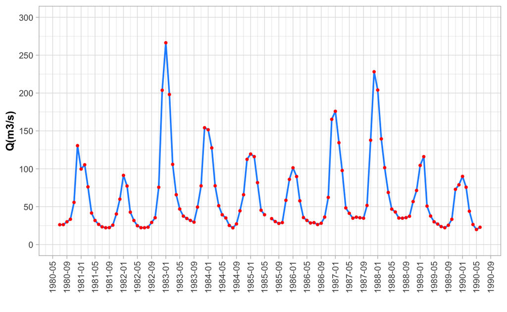

Figure 5: Example of customized time-series plot using the $\texttt{hm\_plot()}$ method in combination with labeling, scaling and theme options available on $\textbf{ggplot2}$.

```r
# library
library(ggplot2)

# plot
gg_hm <-
  guido %>%
    hm_plot(slot_name = "qm",
          col_name = list( c("q_mean") ),
          line_color = "dodgerblue",
          line_size = .7,
          y_lab = "Q(m3/s)", x_lab = "",
          legend_lab = "Mendoza River",
          from = "1980-07-01", to = "1990-06-30")

 # customize the graph
gg_out <-
  gg_hm +
    geom_point(col = "red", size = .8) +
    theme_light() +
    scale_x_date( date_breaks = "4 month", date_labels = "%Y-%m" ) +
    scale_y_continuous(breaks = seq(0, 300, 50), limits = c(0, 300) ) +
    theme(axis.text = element_text(size = 8),
          axis.title.x = element_text(size = 10, face = "bold"),
          axis.text.x = element_text(angle = 90, vjust = 0.5),
          axis.title.y = element_text(size = 10, face = "bold"),
          legend.position = "none")


gg_out
```

### 3.2 Post processing of the HBV.IANIGLA hydrological model

The second case study shows how to use the package for post-processing a numerical model output series. Specifically, it illustrates another `hm_mutate` case but in combination with another package function (`mutate` from dplyr package; Wickham et al. (2021)). The exercise proposes to transform the units of the Cuevas River basin (Figure 3) glacier mass balance simulations from *millimeters of water equivalent* to *meters of water equivalent* and then plot it (Figure 6). The data for this example has been previously loaded into an `hydromet_compact` class object and the reader can download the file from https://gitlab.com/ezetoum27/hydrotoolbox/-/tree/master/my_data).

```r
# dplyr contains mutate()
library(dplyr)

# glacier mass balance simulation
cuevas_mb <- readRDS(file = "data/cuevas_mb.rds" )

cuevas_mb <-
  cuevas_mb %>%
  hm_mutate(slot_name = "compact",
            FUN = mutate,
            `bm (m we)` = round( cuevas / 1000, 2 ),
            .keep = "all"
            )

cuevas_mb %>% hm_show()
```

```
$compact
        date cuevas bm (m we)
1 1981-04-01      0      0.00
2 1982-04-01   1240      1.24
3 1983-04-01    130      0.13
4 1984-04-01    350      0.35
5 1985-04-01    -80     -0.08
6 1986-04-01    350      0.35
```

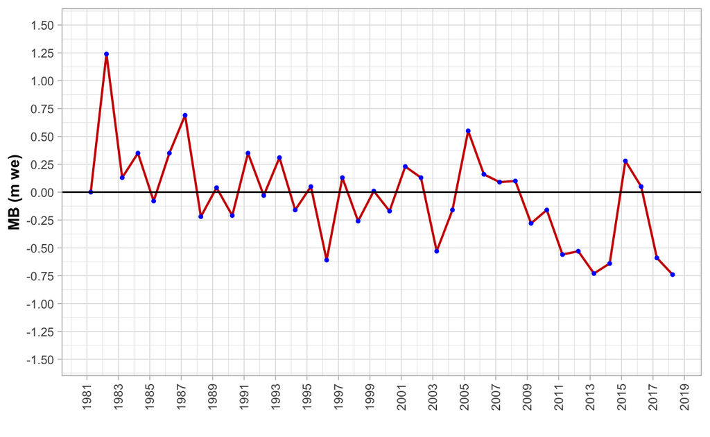

Figure 6: Model post-processing case example for the Cuevas basin annual glacier mass balance.

```r
# use hm_plot()
gg_out <-
  cuevas_mb %>%
  hm_plot(slot_name = "compact",
          col_name = list("bm (m we)"),
          line_color = "red3",
          line_size = .7,
          x_lab = "", y_lab = "MB (m we)"  )

# customize the figure
gg_out +
geom_point(col = "blue", size = .8) +
  geom_hline(yintercept = 0) +
  theme_light() +
  scale_x_date( date_breaks = "2 year", date_labels = "%Y" ) +
  scale_y_continuous(breaks = seq(-1.5, 1.5, 0.25),
                     limits = c(-1.5, 1.5) ) +
  theme(axis.text = element_text(size = 8),
        axis.title.x = element_text(size = 10, face = "bold"),
        axis.text.x = element_text(angle = 90, vjust = 0.5),
        axis.title.y = element_text(size = 10, face = "bold"),
        legend.position = "none")
```

This simple example suggests that hydrotoolbox is not only suited for managing hydrometeorological series, but also for pre and post processing hydrological modeling data.

## 4 Discussion

The R language community has made significant advances in the development of hydrological packages, with many of them focusing on data access, numerical modeling, and pre/post-processing (Slater et al. 2019). The new hydrotoolbox package offers a general framework and methods for working with hydrometeorological time series data management. To our knowledge, this is the first general-purpose package for manipulating and visualizing hydrometeorological data to this date.  
In the literature there are at least two other packages available in the CRAN repository that have some functionalities that could be considered similar to hydrotoolbox, namely hyfo and hydroTSM (Xu 2020; Zambrano-Bigiarini 2020). The first one was designed as part of the European project EUPORIAS, and it is mainly focused on data processing and visualization for hydrological and weather forecasting. Therefore, this package’s functions are specialized in spatial data (e.g., NetCDF) in contrast to hydrotoolbox which focuses on hydrometeorological stations recorded time series. Additionally, hyfo uses ggplot2 for visualization, which can be used to create publication-quality static graphs but not interactive visualizations. The other package, hydroTSM, is oriented towards tasks related to modeling, a shared feature with hydrotoolbox but lacks of a general-purpose system for hydrometeorological time series manipulation. In programming terms, we think that object-oriented programming (encapsulated or functional) is an essential mechanism for dealing with the diversity of available data, while keeping things simpler for the user. In addition, this paradigm makes hydrotoolbox robust in the following aspects:

1. There are specific methods for manipulating and visualizing the objects that can be created with the package. This feature makes the workflow less prone to user error because specific and dedicated functions should be used to access the data.
2. The objects and the modifications that the user makes to the data time series are stored in the same object, avoiding the duplication of records that can occur in other datasets.
3. Once data has been incorporated, it is easy to get access and plot them. Additionally, hydrotoolbox allows saving the metadata which is a desirable feature when working with meteorological stations, data from numerical modeling, or series from large-sample hydrological datasets (Addor et al. 2020).

Although hyfo and hydroTSM overlap with hydrotoolbox in terms of numerical modeling and pre- and post-processing tasks, neither of these two packages (or those mentionned previously) explicitly cover hydrometeorological stations data management nor provide a general working framework for this kind of records.

The package can be used in many applications and the user can also adapt existing functions or packages with hydrotoolbox’s framework. As case examples, the package’s vignettes show how the tidyhydat (Albers 2017) and **weathercan** (LaZerte and Albers 2018) can be combined to work with Canadian hydrometeorological records (see `vignette(topic = "tidyhydat_can", package = "hydrotoolbox")` and `vignette(topic = "weathercan_can", package = "hydrotoolbox")`).

In a recent publication, Addor et al. (2020) made a review of the current state of large-sample hydrology (LSH) datasets. The authors proposed general guidelines to support the creation of future LSH with some of them listed here,

1. **provide basic data for each basin**, with streamflow records being the cornerstone. The metadata should include the name, unique identifier, river and geographical coordinates of each streamgauge, catchment area and elevation info.  
   hydrotoolbox provides all the objects with this metadata.
2. **following standards when naming variables**. Despite the fact that the package doesn’t have the WATER ML-2 (https://www.ogc.org/standards/waterml - last access 2022-10-13) variable names, the purpose of this feature is to ensure the consistency and comparability of environmental datasets. This R package provides with a description for each variable, allowing possible inter-dataset comparisons.
3. **use publicly available code for data processing**, making code for producing the LSH dataset available. This feature is important among free and open source software (FOSS).  
   As a case example, the CAMELS dataset (Addor et al. 2017; Alvarez-Garreton et al. 2018) provides their users with a GitHub repository with code written in R (https://github.com/naddor/camels). Despite this, the repository contains a set of functions instead of a package that can be installed in many operating systems, with documented functions and reproducible examples. The specialized hydrotoolbox may provide a general framework to integrate this functions.

Though there are similar and commonly used software in departments related to the management of hydrometeorological data, they are closed-source proprietary programs. hydrotoolbox is a FOSS, which is a key feature not only from the research perspective but also for hydrological practice. Open source brings transparency to the decision-making and hydrological design processes, and helps to save license money in emerging countries (Hutton et al. 2016).

To conclude this discussion, some users may have used the older hydroToolkit package. This turned out to be an early version of hydrotoolbox that we decided to reform after using it in a large project. We realized that the original five subclasses could be reduced to two, simplifying not only their use but also improving their long-term maintainability. In addition, we decided to improve several methods (e.g., time series visualization) that were limited in functionality. Also, to elaborate the syntax of the functions, methods and their arguments, we followed the suggestions of *The tidyverse style guide* document (Wickham 2023), adapting the package to the new standards used within the community of R programmers.

## 5 Summary

hydrotoolbox is an new contribution to the R hydrological community, as it is specifically designed for working with hydrometeorological station records. The package allows the data to be viewed interactively3 (plotly) or statically (ggplot2) using the same method (`hm_plot`),3 it also allows the use of functions from other packages or created by the user via the `hm_mutate` method.

The case studies show two examples with different aims: the first processed a streamflow record and the second uses a numerical model output to plot results. More complete and varied examples are in the documentation of the package and in3 its vignettes (`vignette(package = "hydrotoolbox")`).

hydrotoolbox is designed to incorporate future improvements. One of them could be functions for visualizing station’s geographical position (using the metadata) on an interactive map, and perhaps to allow the user to plot and compare recorded time series. This new function could use capabilities of the leaflet package, a JavaScript library for producing interactive maps. The main class, `hydromet`, could also combine the functionality of existing packages such as raster (Hijmans 2017) or sf (Pebesma 2018) to include other kind of spatial data (e.g., catchment boundary, soil types, gridded meteorological data, among others). Finally, new classes and methods could be included for processing field data from glacier mass balance studies, an activity closely related to the study of the hydrological cycle in cold regions. This kind of improvements may also make the package useful in other scientific communities such as glaciology.

### 5.1 Supplementary materials

Supplementary materials are available in addition to this article. It can be downloaded at RJ-2023-041.zip

### 5.2 CRAN packages used

waterData, hydroTSM, dataRetrieval, hyfo, hydrotoolbox, HBV.IANIGLA, ggplot2, plotly, dplyr, tidyhydat, hydroToolkit, leaflet, raster, sf

### 5.3 CRAN Task Views implied by cited packages

Databases, Hydrology, ModelDeployment, Phylogenetics, Spatial, SpatioTemporal, TeachingStatistics, WebTechnologies

N. Addor, H. X. Do, C. Alvarez-Garreton, G. Coxon, K. Fowler and P. A. Mendoza. Large-sample hydrology: Recent progress, guidelines for new datasets and grand challenges. *Hydrological Sciences Journal*, 65: 712–725, 2020. URL https://doi.org/10.1080/02626667.2019.1683182 [online; last accessed August 23, 2021].

N. Addor, A. J. Newman, N. Mizukami and M. P. Clark. The CAMELS data set: Catchment attributes and meteorology for large-sample studies. *Hydrology and Earth System Sciences*, 21(10): 5293–5313, 2017. URL https://hess.copernicus.org/articles/21/5293/2017/ [online; last accessed August 26, 2021]. Publisher: Copernicus GmbH.

S. Albers. Tidyhydat: Extract and tidy canadian hydrometric data. *The Journal of Open Source Software*, 2(20): 2017. URL http://dx.doi.org/10.21105/joss.00511.

C. Alvarez-Garreton, P. A. Mendoza, J. P. Boisier, N. Addor, M. Galleguillos, M. Zambrano-Bigiarini, A. Lara, C. Puelma, G. Cortes, R. Garreaud, et al. The CAMELS-CL dataset: Catchment attributes and meteorology for large sample studies – Chile dataset. *Hydrology and Earth System Sciences*, 22(11): 5817–5846, 2018. URL https://www.hydrol-earth-syst-sci.net/22/5817/2018/ [online; last accessed October 29, 2019]. 0371.

K. J. Beven. *Rainfall - Runoff Modelling.* 2 edition Chichester: Wiley, 2012.

J. M. Chambers. *Extending R.* CRC Press, 2017.

O. Conrad, B. Bechtel, M. Bock, H. Dietrich, E. Fischer, L. Gerlitz, J. Wehberg, V. Wichmann and J. Böhner. System for Automated Geoscientific Analyses (SAGA) v. 2.1.4. *Geoscientific Model Development*, 8(7): 2015. URL https://www.geosci-model-dev.net/8/1991/2015/gmd-8-1991-2015.html [online; last accessed January 30, 2020].

B. Czernecki, A. Głogowski and J. Nowosad. Climate: An R Package to Access Free In-Situ Meteorological and Hydrological Datasets For Environmental Assessment. *Sustainability*, 12(1): 2020. URL https://www.mdpi.com/2071-1050/12/1/394 [online; last accessed November 1, 2022].

L. A. De Cicco, D. Lorenz, R. M. Hirsch, W. Watkins and M. Johnson. *dataRetrieval: R packages for discovering and retrieving water data available from u.s. Federal hydrologic web services.* Reston, VA: U.S. Geological Survey; U.S. Geological Survey, 2018. URL https://code.usgs.gov/water/dataRetrieval.

D. Donoho. 50 Years of Data Science. *Journal of Computational and Graphical Statistics*, 26(4): 745–766, 2017. URL https://amstat.tandfonline.com/doi/full/10.1080/10618600.2017.1384734 [online; last accessed April 30, 2020]. Publisher: Taylor & Francis.

Goodinson and Louie. WMO Solid Precipitation Measurement Intercomparison. 67, 318 pages. WMO. 1998. 0348.

R. J. Hijmans. *Raster: Geographic data analysis and modeling.* 2017. URL https://CRAN.R-project.org/package=raster. R package version 2.6-7.

C. Hutton, T. Wagener, J. Freer, D. Han, C. Duffy and B. Arheimer. Most computational hydrology is not reproducible, so is it really science? *Water Resources Research*, 52(10): 7548–7555, 2016. URL https://agupubs.onlinelibrary.wiley.com/doi/abs/10.1002/2016WR019285 [online; last accessed June 18, 2019].

S. E. LaZerte and S. Albers. weathercan: Download and format weather data from environment and climate change canada. *The Journal of Open Source Software*, 3(22): 571, 2018. URL https://joss.theoj.org/papers/10.21105/joss.00571.

E. Pebesma. Simple Features for R: Standardized Support for Spatial Vector Data. *The R Journal*, 10(1): 439–446, 2018. URL https://doi.org/10.32614/RJ-2018-009.

D. Pierce. *ncdf4: Interface to unidata netCDF (version 4 or earlier) format data files.* 2019. URL https://CRAN.R-project.org/package=ncdf4. R package version 1.17.

K. R. Ryberg and A. V. Vecchia. *waterData: Retrieval, analysis, and anomaly calculation of daily hydrologic time series data.* 2017. URL https://CRAN.R-project.org/package=waterData. R package version 1.0.8.

C. Sievert. *Interactive web-based data visualization with r, plotly, and shiny.* Chapman; Hall/CRC, 2020. URL https://plotly-r.com.

L. J. Slater, G. Thirel, S. Harrigan, O. Delaigue, A. Hurley, A. Khouakhi, I. Prodoscimi, C. Vitolo and K. Smith. Using R in hydrology: A review of recent developments and future directions. *Hydrology and Earth System Sciences Discussions*, 1–33, 2019. URL https://www.hydrol-earth-syst-sci-discuss.net/hess-2019-50/ [online; last accessed May 6, 2019].

E. Toum. *HBV.IANIGLA: Modular hydrological model.* 2021. URL https://CRAN.R-project.org/package=HBV.IANIGLA. 0.2.0.

E. Toum. *Hydrotoolbox: Hydrological tools for handling hydro-meteorological data records.* 2022. URL https://CRAN.R-project.org/package=hydrotoolbox. 1.1.0.

E. Toum, M. H. Masiokas, R. Villalba, P. Pitte and L. Ruiz. The HBV.IANIGLA Hydrological Model. *The R Journal*, 13(1): 378–395, 2021. URL https://doi.org/10.32614/RJ-2021-059.

V. Venkatraman. When All Science Becomes Data Science. *Science AAAS*, 2013. URL https://www.sciencemag.org/careers/2013/05/when-all-science-becomes-data-science [online; last accessed April 30, 2020]. Library Catalog: www.sciencemag.org.

C. Vitolo. Hddtools: Hydrological data discovery tools. *The Journal of Open Source Software*, 2(9): 2017. DOI 10.21105/joss.00056.

H. Wickham. *ggplot2: Elegant graphics for data analysis.* Springer-Verlag New York, 2016. URL https://ggplot2.tidyverse.org.

H. Wickham. *The tidyverse style guide.* 2023. URL https://style.tidyverse.org/ [online; last accessed October 4, 2023].

H. Wickham, R. François, L. Henry and K. Müller. *Dplyr: A grammar of data manipulation.* 2021. URL https://CRAN.R-project.org/package=dplyr. R package version 1.0.5.

H. Wickham and G. Grolemund. *R for Data Science: Import, Tidy, Transform, Visualize, and Model Data.* Edición: 1 Sebastopol, CA: O’Reilly Media, 2017.

H. Wickham, J. Hester and J. Bryan. *Readr: Read rectangular text data.* 2022. URL https://CRAN.R-project.org/package=readr. R package version 2.1.2.

Y. Xu. *Hyfo: Hydrology and climate forecasting.* 2020. URL https://CRAN.R-project.org/package=hyfo. R package version 1.4.3.

M. Zambrano-Bigiarini. *hydroTSM: Time series management, analysis and interpolation for hydrological modelling.* 2020. URL https://github.com/hzambran/hydroTSM. R package version 0.6-0 . doi: https://doi.org/10.5281/zenodo.83964.